# G4_Tarek Oueidat_Makram Noureddine

### d- "Length of Service" feature:

```
(1.0, 20.0)
```

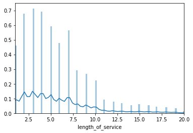

```python
sns.distplot(promo.length_of_service, bins=200)
plt.xlim((1,20))
```

### e- "Recruitment Channel" feature:

```python
channel_perc = promo.groupby('recruitment_channel').is_promoted.count()/(promo.recruitment_channel.count())*100
channel_perc
```

```
recruitment_channel
other       55.550285
referred     2.083637
sourcing    42.366078
Name: is_promoted, dtype: float64
```

```python
channel_percentage = pd.DataFrame(channel_perc)
channel_percentage
```

| recruitment_channel | is_promoted |
| --- | --- |
| other | 55.550285 |
| referred | 2.083637 |
| sourcing | 42.366078 |

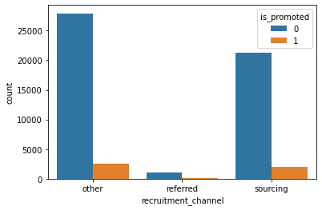

```python
sns.countplot(x='recruitment_channel',hue='is_promoted', data=promo)
```

## 3- Outliers Detection:

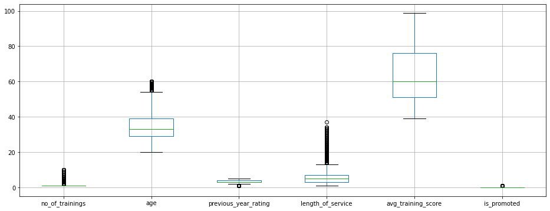

```python
plt.figure(figsize=(16,6))
promo.boxplot()
```

To be able to generalize this model we need to adopt standardized assumptions which is here to target employees at a junior and before top level management since the latter is bound by different criterias and factors to predict promotion.

```python
promo = promo[~(promo['age']>50)]
promo = promo[~(promo['length_of_service']>25)]
```

```python
print('The number of outliers in the number of trainings category from 1.5 STD above the mean is {}'.format(promo.no_of_trainings[promo.no_of_trainings > (np.mean(promo.no_of_trainings)+ 1.5*np.std(promo.no_of_trainings))].sum()))
print('The number of outliers in the age category from 1.5 STD above the mean is {}'.format(promo.no_of_trainings[promo.age > (np.mean(promo.age)+1.5*np.std(promo.age))].sum()))
print('The number of outliers in the length of service category from 1.5 STD above the mean is {}'.format(promo.no_of_trainings[promo.length_of_service > (np.mean(promo.length_of_service)+1.5*np.std(promo.length_of_service))].sum()))
print('The number of outliers in the previous year rating category from 1.5 STD below the mean is {}'.format(promo.previous_year_rating[promo.previous_year_rating < (np.mean(promo.previous_year_rating)-1.5*np.std(promo.no_of_trainings))].sum()))
```

```
The number of outliers in the number of trainings category from 1.5 STD above the mean is 8056
The number of outliers in the age category from 1.5 STD above the mean is 6335
The number of outliers in the length of service category from 1.5 STD above the mean is 5000
The number of outliers in the previous year rating category from 1.5 STD below the mean is 13855.0
```

```python
promo.to_csv('C:/Users/Makram/Desktop/MSBA 315/hr analytics/CLEANED Files/promo_cleaned.csv', index=False)
```

```python
promo_cleaned = pd.read_csv('C:/Users/Makram/Desktop/MSBA 315/hr analytics/CLEANED Files/promo_cleaned.csv')
```

```python
promo_cleaned
```

|  | department | education | gender | recruitment_channel | no_of_trainings | age | previous_year_rating | length_of_service | awards_won? | avg_training_score | is_promoted |
| --- | --- | --- | --- | --- | --- | --- | --- | --- | --- | --- | --- |
| 0 | Sales & Marketing | Master's & above | f | sourcing | 1 | 35 | 5.0 | 8 | no | 49 | 0 |
| 1 | Operations | Bachelor's | m | other | 1 | 30 | 5.0 | 4 | no | 60 | 0 |
| 2 | Sales & Marketing | Bachelor's | m | sourcing | 1 | 34 | 3.0 | 7 | no | 50 | 0 |
| 3 | Sales & Marketing | Bachelor's | m | other | 2 | 39 | 1.0 | 10 | no | 50 | 0 |
| 4 | Technology | Bachelor's | m | other | 1 | 45 | 3.0 | 2 | no | 73 | 0 |
| ... | ... | ... | ... | ... | ... | ... | ... | ... | ... | ... | ... |
| 51949 | Technology | Bachelor's | m | sourcing | 1 | 48 | 3.0 | 17 | no | 78 | 0 |
| 51950 | Operations | Master's & above | f | other | 1 | 37 | 2.0 | 6 | no | 56 | 0 |
| 51951 | Analytics | Bachelor's | m | other | 1 | 27 | 5.0 | 3 | no | 79 | 0 |
| 51952 | Sales & Marketing | NaN | m | sourcing | 1 | 29 | 1.0 | 2 | no | 45 | 0 |
| 51953 | HR | Bachelor's | m | other | 1 | 27 | 1.0 | 5 | no | 49 | 0 |

51954 rows × 11 columns

## 4- Train & Test Split

After the final dataframe is created, we will split the data into train and test using the startified method in order to keep the same proportion of target variable in both datasets

```python
train, test = train_test_split(promo_cleaned, test_size=0.2, random_state=42, shuffle=True,
                                           stratify=promo_cleaned.is_promoted)
```

```python
#train.to_csv('C:/Users/Makram/Desktop/MSBA 315/hr analytics/CLEANED Files/train.csv', index=False)
#test.to_csv('C:/Users/Makram/Desktop/MSBA 315/hr analytics/CLEANED Files/test.csv', index=False)
```

# TRAIN DATA PREPROCESSING

Now we will begin our work of preprocessing and model buidling using our train subset

```python
train
```

|  | department | education | gender | recruitment_channel | no_of_trainings | age | previous_year_rating | length_of_service | awards_won? | avg_training_score | is_promoted |
| --- | --- | --- | --- | --- | --- | --- | --- | --- | --- | --- | --- |
| 27367 | Procurement | Bachelor's | f | sourcing | 1 | 38 | 3.0 | 7 | no | 74 | 0 |
| 224 | HR | Bachelor's | f | other | 1 | 26 | 4.0 | 3 | no | 50 | 0 |
| 6172 | Technology | Bachelor's | m | other | 1 | 45 | 1.0 | 4 | no | 81 | 0 |
| 46602 | Operations | Bachelor's | f | other | 1 | 43 | 5.0 | 10 | no | 59 | 1 |
| 42852 | Operations | Master's & above | m | sourcing | 1 | 34 | 5.0 | 3 | no | 57 | 0 |
| ... | ... | ... | ... | ... | ... | ... | ... | ... | ... | ... | ... |
| 16086 | Sales & Marketing | Bachelor's | m | sourcing | 1 | 26 | 5.0 | 3 | no | 55 | 0 |
| 50105 | Analytics | Bachelor's | m | sourcing | 2 | 31 | 4.0 | 6 | no | 84 | 0 |
| 42165 | Procurement | Bachelor's | f | sourcing | 2 | 33 | 5.0 | 6 | no | 70 | 0 |
| 48979 | Technology | Bachelor's | m | other | 1 | 31 | 3.0 | 8 | no | 79 | 0 |
| 31775 | Operations | Bachelor's | m | sourcing | 1 | 28 | 3.0 | 3 | no | 56 | 0 |

41563 rows × 11 columns

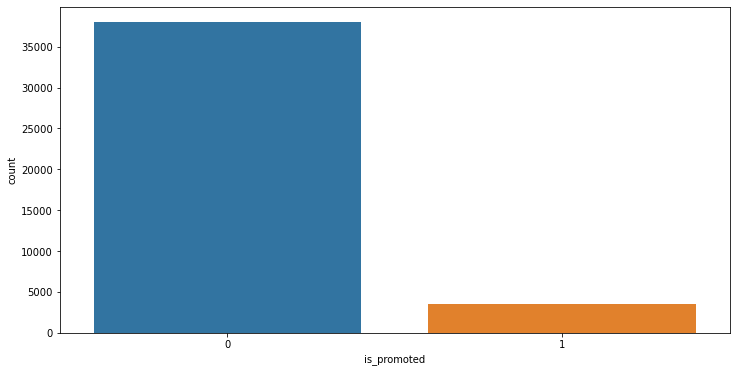

```python
plt.subplots(figsize=(12,6))
sns.countplot(x='is_promoted',data=train)
```

```python
# Assign X as a DataFrame of features and y as a Series of the outcome variable
train_features = train.drop('is_promoted', 1)
train_lables = train.is_promoted
```

```python
train_features.info()
```

```
<class 'pandas.core.frame.DataFrame'>
Int64Index: 41563 entries, 27367 to 31775
Data columns (total 10 columns):
 #   Column                Non-Null Count  Dtype
---  ------                --------------  -----
 0   department            41563 non-null  object
 1   education             39688 non-null  object
 2   gender                41563 non-null  object
 3   recruitment_channel   41563 non-null  object
 4   no_of_trainings       41563 non-null  int64
 5   age                   41563 non-null  int64
 6   previous_year_rating  38279 non-null  float64
 7   length_of_service     41563 non-null  int64
 8   awards_won?           41563 non-null  object
 9   avg_training_score    41563 non-null  int64
dtypes: float64(1), int64(4), object(5)
memory usage: 4.7+ MB
```

## Correlation Heatmap

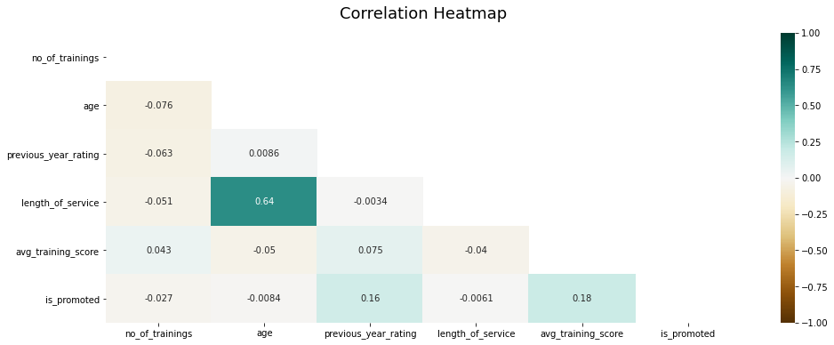

```python
plt.figure(figsize=(16, 6))
# define the mask to set the values in the upper triangle to True
mask = np.triu(np.ones_like(train.corr(), dtype=np.bool))
heatmap = sns.heatmap(train.corr(), mask=mask, vmin=-1, vmax=1, annot=True, cmap='BrBG')
heatmap.set_title('Correlation Heatmap', fontdict={'fontsize':18}, pad=16);
```

The above correlation matrix shows us that there are no severe correlation between any of the numerical features

## Outlier Function Detection

The below function works by detecting all the data not within the lower and upper bound set and replace them with NAs so we can later on replace those missing values with the median of the data within the bounds set

```python
from sklearn.base import BaseEstimator,TransformerMixin


class OutlierRemover(BaseEstimator,TransformerMixin):
    def __init__(self,factor=1.5):
        self.factor = factor

    def outlier_removal(self,X,y=None):
        X = pd.Series(X).copy()
        q1 = X.quantile(0.25)
        q3 = X.quantile(0.75)
        iqr = q3 - q1
        lower_bound = q1 - (self.factor * iqr)
        upper_bound = q3 + (self.factor * iqr)
        X.loc[((X < lower_bound) | (X > upper_bound))] = np.nan
        return pd.Series(X)

    def fit(self,X,y=None):
        return self

    def transform(self,X,y=None):
        return X.apply(self.outlier_removal)

outlier_remover = OutlierRemover()
```

```python
train_num_features = train_features.select_dtypes(include=[np.number])
train_num_cat = train_features.select_dtypes(exclude=[np.number])
```

```python
train_num_features=outlier_remover.fit_transform(train_num_features)
```

```python
train_num_features.describe()
```

|  | no_of_trainings | age | previous_year_rating | length_of_service | avg_training_score |
| --- | --- | --- | --- | --- | --- |
| count | 33439.0 | 41563.000000 | 33566.000000 | 39776.000000 | 41563.000000 |
| mean | 1.0 | 33.695210 | 3.658136 | 4.989491 | 63.414792 |
| std | 0.0 | 6.170899 | 0.970964 | 2.857089 | 13.404470 |
| min | 1.0 | 20.000000 | 2.000000 | 1.000000 | 39.000000 |
| 25% | 1.0 | 29.000000 | 3.000000 | 3.000000 | 51.000000 |
| 50% | 1.0 | 33.000000 | 3.000000 | 5.000000 | 60.000000 |
| 75% | 1.0 | 38.000000 | 5.000000 | 7.000000 | 76.000000 |
| max | 1.0 | 50.000000 | 5.000000 | 13.000000 | 99.000000 |

```python
train_num_features.isna().sum()
```

```
no_of_trainings         8124
age                        0
previous_year_rating    7997
length_of_service       1787
avg_training_score         0
dtype: int64
```

## Numerical Imputer

The belwo numerical imputer will replace all the NA values with the median of each column

```python
from sklearn.impute import SimpleImputer

imputer = SimpleImputer(strategy="median")
```

```python
train_num_features = train_features.select_dtypes(include=[np.number])
```

```python
train_features.shape,train_num_features.shape
```

```
((41563, 10), (41563, 5))
```

```python
imputer.fit(train_num_features)
```

```
SimpleImputer(strategy='median')
```

```python
imputer.statistics_
```

```
array([ 1., 33.,  3.,  5., 60.])
```

```python
X1 = imputer.transform(train_num_features)
```

```python
X1
```

```
array([[ 1., 38.,  3.,  7., 74.],
       [ 1., 26.,  4.,  3., 50.],
       [ 1., 45.,  1.,  4., 81.],
       ...,
       [ 2., 33.,  5.,  6., 70.],
       [ 1., 31.,  3.,  8., 79.],
       [ 1., 28.,  3.,  3., 56.]])
```

```python
train_num_features = pd.DataFrame(X1, columns=train_num_features.columns,
                          index=train_num_features.index)
```

```python
sample_incomplete_rows = train[train.isnull().any(axis=1)].head()
sample_incomplete_rows
```

|  | department | education | gender | recruitment_channel | no_of_trainings | age | previous_year_rating | length_of_service | awards_won? | avg_training_score | is_promoted |
| --- | --- | --- | --- | --- | --- | --- | --- | --- | --- | --- | --- |
| 30610 | R&D | Master's & above | m | sourcing | 1 | 27 | NaN | 1 | no | 85 | 0 |
| 41205 | Sales & Marketing | NaN | m | sourcing | 1 | 36 | 4.0 | 9 | no | 53 | 0 |
| 28405 | Sales & Marketing | NaN | m | sourcing | 1 | 41 | 2.0 | 10 | no | 51 | 0 |
| 48148 | Procurement | NaN | m | other | 5 | 34 | 3.0 | 6 | no | 69 | 0 |
| 43873 | Procurement | Below Secondary | f | other | 1 | 24 | NaN | 1 | no | 66 | 0 |

```python
train_num_features.loc[sample_incomplete_rows.index.values]
```

|  | no_of_trainings | age | previous_year_rating | length_of_service | avg_training_score |
| --- | --- | --- | --- | --- | --- |
| 30610 | 1.0 | 27.0 | 3.0 | 1.0 | 85.0 |
| 41205 | 1.0 | 36.0 | 4.0 | 9.0 | 53.0 |
| 28405 | 1.0 | 41.0 | 2.0 | 10.0 | 51.0 |
| 48148 | 5.0 | 34.0 | 3.0 | 6.0 | 69.0 |
| 43873 | 1.0 | 24.0 | 3.0 | 1.0 | 66.0 |

## Categorical Imputer

The below categorical imputer will replace all the NA values with a constant value named "missing_value"

```python
train_features_cat = train_features.select_dtypes(exclude=[np.number])
```

```python
train_features_cat
```

|  | department | education | gender | recruitment_channel | awards_won? |
| --- | --- | --- | --- | --- | --- |
| 27367 | Procurement | Bachelor's | f | sourcing | no |
| 224 | HR | Bachelor's | f | other | no |
| 6172 | Technology | Bachelor's | m | other | no |
| 46602 | Operations | Bachelor's | f | other | no |
| 42852 | Operations | Master's & above | m | sourcing | no |
| ... | ... | ... | ... | ... | ... |
| 16086 | Sales & Marketing | Bachelor's | m | sourcing | no |
| 50105 | Analytics | Bachelor's | m | sourcing | no |
| 42165 | Procurement | Bachelor's | f | sourcing | no |
| 48979 | Technology | Bachelor's | m | other | no |
| 31775 | Operations | Bachelor's | m | sourcing | no |

41563 rows × 5 columns

```python
train_features_cat.info()
```

```
<class 'pandas.core.frame.DataFrame'>
Int64Index: 41563 entries, 27367 to 31775
Data columns (total 5 columns):
 #   Column               Non-Null Count  Dtype
---  ------               --------------  -----
 0   department           41563 non-null  object
 1   education            39688 non-null  object
 2   gender               41563 non-null  object
 3   recruitment_channel  41563 non-null  object
 4   awards_won?          41563 non-null  object
dtypes: object(5)
memory usage: 3.2+ MB
```

```python
cat_imputer = SimpleImputer(strategy="constant")
```

```python
cat_imputer.fit(train_features_cat)
```

```
SimpleImputer(strategy='constant')
```

```python
X_cat = cat_imputer.transform(train_features_cat)
```

```python
train_features_cat = pd.DataFrame(X_cat, columns=train_features_cat.columns,
                          index=train_features_cat.index)
```

```python
train_features.shape,train_features_cat.shape
```

```
((41563, 10), (41563, 5))
```

```python
train_features_cat.info()
```

```
<class 'pandas.core.frame.DataFrame'>
Int64Index: 41563 entries, 27367 to 31775
Data columns (total 5 columns):
 #   Column               Non-Null Count  Dtype
---  ------               --------------  -----
 0   department           41563 non-null  object
 1   education            41563 non-null  object
 2   gender               41563 non-null  object
 3   recruitment_channel  41563 non-null  object
 4   awards_won?          41563 non-null  object
dtypes: object(5)
memory usage: 3.2+ MB
```

```python
train_features_cat['education'].unique()
```

```
array(["Bachelor's", "Master's & above", 'missing_value',
       'Below Secondary'], dtype=object)
```

### OneHotEncoder

After we repalced all categorical NAs, we will preform a OneHotEncoder on the categorical variables

```python
from sklearn.preprocessing import OneHotEncoder

cat_encoder = OneHotEncoder()
train_features_cat_1hot = cat_encoder.fit_transform(train_features_cat)
train_features_cat_1hot
```

```
<41563x20 sparse matrix of type '<class 'numpy.float64'>'
	with 207815 stored elements in Compressed Sparse Row format>
```

```python
train_features_cat_1hot.toarray()
```

```
array([[0., 0., 0., ..., 1., 1., 0.],
       [0., 0., 1., ..., 0., 1., 0.],
       [0., 0., 0., ..., 0., 1., 0.],
       ...,
       [0., 0., 0., ..., 1., 1., 0.],
       [0., 0., 0., ..., 0., 1., 0.],
       [0., 0., 0., ..., 1., 1., 0.]])
```

```python
cat_encoder.categories_
```

```
[array(['Analytics', 'Finance', 'HR', 'Legal', 'Operations', 'Procurement',
        'R&D', 'Sales & Marketing', 'Technology'], dtype=object),
 array(["Bachelor's", 'Below Secondary', "Master's & above",
        'missing_value'], dtype=object),
 array(['f', 'm'], dtype=object),
 array(['other', 'referred', 'sourcing'], dtype=object),
 array(['no', 'yes'], dtype=object)]
```

## Pipeline for numerical features

Now let's build a pipeline for preprocessing the numerical attributes:

```python
###### from sklearn.pipeline import Pipeline
from sklearn.preprocessing import MinMaxScaler
from sklearn.pipeline import Pipeline

num_pipeline = Pipeline([
        ('Outlier_Remover', OutlierRemover()),
        ('imputer', SimpleImputer(strategy="median")),
        ('MinMaxScaler', MinMaxScaler()),
        ])
```

```python
y_train = train["is_promoted"].copy()
X_train = train.drop("is_promoted", axis=1)
```

```python
# train.info()
X_train_num = X_train.select_dtypes(include=[np.number])
X_train_cat = X_train.select_dtypes(exclude=[np.number])
```

```python
X_train_num_tr = num_pipeline.fit_transform(X_train_num)
print(X_train_num_tr.shape)
X_train_num_tr
```

```
(41563, 5)
```

```
array([[0.        , 0.6       , 0.33333333, 0.5       , 0.58333333],
       [0.        , 0.2       , 0.66666667, 0.16666667, 0.18333333],
       [0.        , 0.83333333, 0.33333333, 0.25      , 0.7       ],
       ...,
       [0.        , 0.43333333, 1.        , 0.41666667, 0.51666667],
       [0.        , 0.36666667, 0.33333333, 0.58333333, 0.66666667],
       [0.        , 0.26666667, 0.33333333, 0.16666667, 0.28333333]])
```

```python
X_train_num_tr_pd = pd.DataFrame(
    X_train_num_tr,
    columns=list(X_train_num.columns),
    index=X_train_num.index)
X_train_num_tr_pd
```

|  | no_of_trainings | age | previous_year_rating | length_of_service | avg_training_score |
| --- | --- | --- | --- | --- | --- |
| 27367 | 0.0 | 0.600000 | 0.333333 | 0.500000 | 0.583333 |
| 224 | 0.0 | 0.200000 | 0.666667 | 0.166667 | 0.183333 |
| 6172 | 0.0 | 0.833333 | 0.333333 | 0.250000 | 0.700000 |
| 46602 | 0.0 | 0.766667 | 1.000000 | 0.750000 | 0.333333 |
| 42852 | 0.0 | 0.466667 | 1.000000 | 0.166667 | 0.300000 |
| ... | ... | ... | ... | ... | ... |
| 16086 | 0.0 | 0.200000 | 1.000000 | 0.166667 | 0.266667 |
| 50105 | 0.0 | 0.366667 | 0.666667 | 0.416667 | 0.750000 |
| 42165 | 0.0 | 0.433333 | 1.000000 | 0.416667 | 0.516667 |
| 48979 | 0.0 | 0.366667 | 0.333333 | 0.583333 | 0.666667 |
| 31775 | 0.0 | 0.266667 | 0.333333 | 0.166667 | 0.283333 |

41563 rows × 5 columns

## Categorical Pipeline

Now let's build a pipeline for preprocessing the categorical attributes:

```python
cat_pipeline = Pipeline([
        ('imputer', SimpleImputer(strategy="constant")),
        ("cat", OneHotEncoder(handle_unknown='ignore')),
    ])
```

## ColumnTransform

Now that both pipelines are ready, we will use the column transformer so we can create a full pipeline that transforms in one step all our features whether they're numerical or categorical

```python
from sklearn.compose import ColumnTransformer

num_attribs = list(X_train_num)
cat_attribs = list(X_train_cat)

full_pipeline = ColumnTransformer([
        ("num", num_pipeline, num_attribs),
        ("cat", cat_pipeline, cat_attribs),
    ])

train_prepared = full_pipeline.fit_transform(X_train)
```

```python
train_prepared
```

```
array([[0.        , 0.6       , 0.33333333, ..., 1.        , 1.        ,
        0.        ],
       [0.        , 0.2       , 0.66666667, ..., 0.        , 1.        ,
        0.        ],
       [0.        , 0.83333333, 0.33333333, ..., 0.        , 1.        ,
        0.        ],
       ...,
       [0.        , 0.43333333, 1.        , ..., 1.        , 1.        ,
        0.        ],
       [0.        , 0.36666667, 0.33333333, ..., 0.        , 1.        ,
        0.        ],
       [0.        , 0.26666667, 0.33333333, ..., 1.        , 1.        ,
        0.        ]])
```

# MODELING

In the below section we will train our data using using the below selected models to compute the following list of metrics (Accuracy, Precision, AUC_ROC, Recall, F1 Score) while focusing on the precision metric since we're more interested in the False positive category (an employee labeled as being promoted while it's not) more than any other category :

1- Logistic Regression

2- K Nearest Neighbour

3- ComplimentNB

4- Linear Support Vector Classification

5- Decision Tree Classifier

6- Random Forest Classifier

7- Gradient Boosting Classifier

8- Balanced Bagging Classifier

In all models we will use the Grid Search methid to further optimize our paramters and select the best one

```python
from numpy import mean
from sklearn.model_selection import cross_validate
from sklearn.model_selection import StratifiedKFold
from imblearn.pipeline import Pipeline as imbpipeline
from imblearn.over_sampling import SMOTE
from imblearn.under_sampling import RandomUnderSampler
from sklearn.model_selection import GridSearchCV
from sklearn.naive_bayes import ComplementNB
from sklearn.model_selection import RepeatedStratifiedKFold

# Set the Cross Validation
cv = StratifiedKFold(n_splits=5,shuffle=True,random_state=42)
```

## Logistic Regression

```python
from sklearn.linear_model import LogisticRegression

# define pipeline
model = LogisticRegression()
over = SMOTE(sampling_strategy=0.2)
under = RandomUnderSampler(sampling_strategy=0.2)
steps = [ ('over', over), ('under',under),('model', model)]
pipeline = imbpipeline(steps=steps)

param_grid_lr  = {'model__C': [0.1,0.15,0.2,],
                  'model__tol': [0.0001,0.001,0.01],
                    'model__max_iter':[1000,5000,10000],
              'model__random_state': [42]
             }

grid_LR = GridSearchCV(pipeline, param_grid_lr, scoring=['accuracy','roc_auc','recall','precision','f1'],refit='precision', cv=cv,verbose = 3,return_train_score=True)

grid_LR.fit(train_prepared, y_train)
```

[output not shown]

[output cut: 119 more lines]

```
GridSearchCV(cv=StratifiedKFold(n_splits=5, random_state=42, shuffle=True),
             estimator=Pipeline(steps=[('over', SMOTE(sampling_strategy=0.2)),
                                       ('under',
                                        RandomUnderSampler(sampling_strategy=0.2)),
                                       ('model', LogisticRegression())]),
             param_grid={'model__C': [0.1, 0.15, 0.2],
                         'model__max_iter': [1000, 5000, 10000],
                         'model__random_state': [42],
                         'model__tol': [0.0001, 0.001, 0.01]},
             refit='precision', return_train_score=True,
             scoring=['accuracy', 'roc_auc', 'recall', 'precision', 'f1'],
             verbose=3)
```

```python
# print best parameter after tuning
grid_LR_best_parameters=grid_LR.best_params_
print(grid_LR_best_parameters)

# print best estimator after tuning
grid_LR_best_estimator=grid_LR.best_estimator_
print(grid_LR_best_estimator)

# print grid search cross validation results
grid_LR_res = grid_LR.cv_results_
print(grid_LR_res)
```

[output not shown]

[output cut: 361 more lines]

[output not shown]

```python
grid_LR_res.keys()
```

```
dict_keys(['mean_fit_time', 'std_fit_time', 'mean_score_time', 'std_score_time', 'param_model__C', 'param_model__max_iter', 'param_model__random_state', 'param_model__tol', 'params', 'split0_test_accuracy', 'split1_test_accuracy', 'split2_test_accuracy', 'split3_test_accuracy', 'split4_test_accuracy…
```

```python
grid_LR.best_estimator_
```

```
Pipeline(steps=[('over', SMOTE(sampling_strategy=0.2)),
                ('under', RandomUnderSampler(sampling_strategy=0.2)),
                ('model',
                 LogisticRegression(C=0.15, max_iter=1000, random_state=42,
                                    tol=0.01))])
```

Now we will plot the learning curve using the precision scored as a metric

```python
from sklearn.model_selection import learning_curve

# Plot learning curve
def plot_learning_curve(estimator, title, X, y, ylim=None, cv=None,
                        n_jobs=-1, train_sizes=np.linspace(.1, 1.0, 5)):
    """
    Generate a simple plot of the test and traning learning curve.

    Parameters
    ----------
    estimator : object type that implements the "fit" and "predict" methods
        An object of that type which is cloned for each validation.

    title : string
        Title for the chart.

    X : array-like, shape (n_samples, n_features)
        Training vector, where n_samples is the number of samples and
        n_features is the number of features.

    y : array-like, shape (n_samples) or (n_samples, n_features), optional
        Target relative to X for classification or regression;
        None for unsupervised learning.

    ylim : tuple, shape (ymin, ymax), optional
        Defines minimum and maximum yvalues plotted.

    cv : integer, cross-validation generator, optional
        If an integer is passed, it is the number of folds (defaults to 3).
        Specific cross-validation objects can be passed, see
        sklearn.cross_validation module for the list of possible objects

    n_jobs : integer, optional
        Number of jobs to run in parallel (default 1).

    x1 = np.linspace(0, 10, 8, endpoint=True) produces
        8 evenly spaced points in the range 0 to 10
    """


    plt.figure()
    plt.title(title)
    if ylim is not None:
        plt.ylim(*ylim)

    plt.xlabel("Training examples")
    plt.ylabel("Precision")
    train_sizes, train_scores, test_scores = learning_curve(
        estimator, X, y, cv=cv, n_jobs=n_jobs, train_sizes=train_sizes,scoring='precision')
    train_scores_mean = np.mean(train_scores, axis=1)
    train_scores_std = np.std(train_scores, axis=1)
    test_scores_mean = np.mean(test_scores, axis=1)
    test_scores_std = np.std(test_scores, axis=1)
    plt.grid()

    plt.fill_between(train_sizes, train_scores_mean - train_scores_std,
                     train_scores_mean + train_scores_std, alpha=0.1,
                     color="r")
    plt.fill_between(train_sizes, test_scores_mean - test_scores_std,
                     test_scores_mean + test_scores_std, alpha=0.1, color="g")
    plt.plot(train_sizes, train_scores_mean, 'o-', color="r",
             label="Training score")
    plt.plot(train_sizes, test_scores_mean, 'o-', color="g",
             label="Cross-validation score")

    plt.legend(loc="best")
    return plt
```

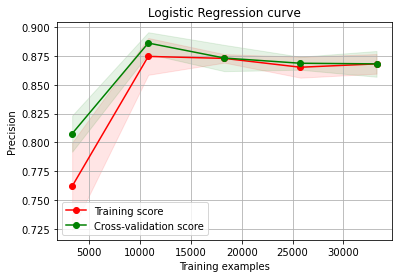

```python
# Logistic REgression - Learning Curve
plot_learning_curve(estimator = grid_LR.best_estimator_,title = "Logistic Regression curve",
                    X = train_prepared, y = y_train, cv = cv);
```

```python
for mean_score, params in zip(grid_LR_res["mean_test_precision"], grid_LR_res["params"]):
    print(f"score = {mean_score} <- parameters {params}")
```

```
score = 0.8587744435316594 <- parameters {'model__C': 0.1, 'model__max_iter': 1000, 'model__random_state': 42, 'model__tol': 0.0001}
score = 0.8658565918763536 <- parameters {'model__C': 0.1, 'model__max_iter': 1000, 'model__random_state': 42, 'model__tol': 0.001}
score = 0.8643763661201366 <- parameters {'model__C': 0.1, 'model__max_iter': 1000, 'model__random_state': 42, 'model__tol': 0.01}
score = 0.8724397457712441 <- parameters {'model__C': 0.1, 'model__max_iter': 5000, 'model__random_state': 42, 'model__tol': 0.0001}
score = 0.8685681069213445 <- parameters {'model__C': 0.1, 'model__max_iter': 5000, 'model__random_state': 42, 'model__tol': 0.001}
score = 0.8655589471658812 <- parameters {'model__C': 0.1, 'model__max_iter': 5000, 'model__random_state': 42, 'model__tol': 0.01}
score = 0.870505594993244 <- parameters {'model__C': 0.1, 'model__max_iter': 10000, 'model__random_state': 42, 'model__tol': 0.0001}
score = 0.8667293407801349 <- parameters {'model__C': 0.1, 'model__max_iter': 10000, 'model__random_state': 42, 'model__tol': 0.001}
score = 0.86614902329149 <- parameters {'model__C': 0.1, 'model__max_iter': 10000, 'model__random_state': 42, 'model__tol': 0.01}
score = 0.8653788573667228 <- parameters {'model__C': 0.15, 'model__max_iter': 1000, 'model__random_state': 42, 'model__tol': 0.0001}
score = 0.8703693230130364 <- parameters {'model__C': 0.15, 'model__max_iter': 1000, 'model__random_state': 42, 'model__tol': 0.001}
score = 0.8729238518639508 <- parameters {'model__C': 0.15, 'model__max_iter': 1000, 'model__random_state': 42, 'model__tol': 0.01}
score = 0.8715563100903931 <- parameters {'model__C': 0.15, 'model__max_iter': 5000, 'model__random_state': 42, 'model__tol': 0.0001}
score = 0.8653076655530028 <- parameters {'model__C': 0.15, 'model__max_iter': 5000, 'model__random_state': 42, 'model__tol': 0.001}
score = 0.865048813324686 <- parameters {'model__C': 0.15, 'model__max_iter': 5000, 'model__random_state': 42, 'model__tol': 0.01}
score = 0.8635026380714879 <- parameters {'model__C': 0.15, 'model__max_iter': 10000, 'model__random_state': 42, 'model__tol': 0.0001}
score = 0.8712411026606557 <- parameters {'model__C': 0.15, 'model__max_iter': 10000, 'model__random_state': 42, 'model__tol': 0.001}
score = 0.8640207825574571 <- parameters {'model__C': 0.15, 'model__max_iter': 10000, 'model__random_state': 42, 'model__tol': 0.01}
score = 0.86404146892593 <- parameters {'model__C': 0.2, 'model__max_iter': 1000, 'model__random_state': 42, 'model__tol': 0.0001}
score = 0.869955512091957 <- parameters {'model__C': 0.2, 'model__max_iter': 1000, 'model__random_state': 42, 'model__tol': 0.001}
score = 0.8613773607610622 <- parameters {'model__C': 0.2, 'model__max_iter': 1000, 'model__random_state': 42, 'model__tol': 0.01}
score = 0.8679185304915469 <- parameters {'model__C': 0.2, 'model__max_iter': 5000, 'model__random_state': 42, 'model__tol': 0.0001}
score = 0.8664857649008024 <- parameters {'model__C': 0.2, 'model__max_iter': 5000, 'model__random_state': 42, 'model__tol': 0.001}
score = 0.865112232015188 <- parameters {'model__C': 0.2, 'model__max_iter': 5000, 'model__random_state': 42, 'model__tol': 0.01}
score = 0.8640772431626651 <- parameters {'model__C': 0.2, 'model__max_iter': 10000, 'model__random_state': 42, 'model__tol': 0.0001}
score = 0.868389661931206 <- parameters {'model__C': 0.2, 'model__max_iter': 10000, 'model__random_state': 42, 'model__tol': 0.001}
score = 0.8631687118375841 <- parameters {'model__C': 0.2, 'model__max_iter': 10000, 'model__random_state': 42, 'model__tol': 0.01}
```

```python
LR_precision_mean= mean(grid_LR_res["mean_test_precision"])
LR_precision_mean
```

```
0.8666234811507713
```

```python
LR_roc_auc_mean= mean(grid_LR_res["mean_test_roc_auc"])
LR_recall_mean= mean(grid_LR_res["mean_test_recall"])
LR_f1_mean= mean(grid_LR_res["mean_test_f1"])
LR_accuracy_mean= mean(grid_LR_res["mean_test_accuracy"])
```

Now we will display the coefficient importance for our model

```python
importance = grid_LR_best_estimator['model'].coef_
importance
```

```
array([[ 0.00000000e+00, -6.10901151e-01,  1.56785602e+00,
        -6.68121875e-02,  1.01742998e+01, -2.71370925e+00,
         1.00075200e+00,  2.30086214e+00,  6.15231245e-01,
         1.20380745e+00, -3.73988636e-01, -3.06933535e+00,
         2.75542061e+00, -1.71967144e+00,  1.34553647e-01,
        -1.42707293e-01,  3.54062666e-01, -3.46540238e-01,
        -3.31450218e-06, -6.27903820e-04,  1.92059775e-02,
        -1.11553017e-02, -8.68189417e-03, -8.16868980e-01,
         8.16237762e-01]])
```

```python
cat_encoder = full_pipeline.named_transformers_["cat"]
cat_encoder
```

```
Pipeline(steps=[('imputer', SimpleImputer(strategy='constant')),
                ('cat', OneHotEncoder(handle_unknown='ignore'))])
```

```python
cat_encoder.categories_
```

```
[array(['Analytics', 'Finance', 'HR', 'Legal', 'Operations', 'Procurement',
        'R&D', 'Sales & Marketing', 'Technology'], dtype=object),
 array(["Bachelor's", 'Below Secondary', "Master's & above",
        'missing_value'], dtype=object),
 array(['f', 'm'], dtype=object),
 array(['other', 'referred', 'sourcing'], dtype=object),
 array(['no', 'yes'], dtype=object)]
```

```python
cat_one_hot_attribs = list(cat_encoder.categories_[0])+ list(cat_encoder.categories_[1])+list(cat_encoder.categories_[2])+ list(cat_encoder.categories_[3])+list(cat_encoder.categories_[4])
```

```python
list(importance[0])
```

```
[0.0,
 -0.6109011514269594,
 1.5678560227127984,
 -0.06681218747615726,
 10.174299786651261,
 -2.7137092507213256,
 1.0007520025983225,
 2.3008621429785974,
 0.6152312450438661,
 1.203807453467581,
 -0.3739886356563001,
 -3.06933534855321,
 2.755420612177598,
 -1.7196714396567347,
 0.13455364704119052,
 -0.1427072925456033,
 0.3540626656477627,
 -0.34654023846441584,
 -3.314502175529041e-06,
 -0.0006279038199536254,
 0.01920597752818765,
 -0.011155301683409585,
 -0.008681894167148006,
 -0.8168689799473546,
 0.816237761625806]
```

```python
attributes = num_attribs +  cat_one_hot_attribs
ax=sorted(zip(importance[0], attributes), reverse=True)
ax
```

```
[(10.174299786651261, 'avg_training_score'),
 (2.755420612177598, 'Sales & Marketing'),
 (2.3008621429785974, 'HR'),
 (1.5678560227127984, 'previous_year_rating'),
 (1.203807453467581, 'Operations'),
 (1.0007520025983225, 'Finance'),
 (0.816237761625806, 'yes'),
 (0.6152312450438661, 'Legal'),
 (0.3540626656477627, "Master's & above"),
 (0.13455364704119052, "Bachelor's"),
 (0.01920597752818765, 'other'),
 (0.0, 'no_of_trainings'),
 (-3.314502175529041e-06, 'f'),
 (-0.0006279038199536254, 'm'),
 (-0.008681894167148006, 'sourcing'),
 (-0.011155301683409585, 'referred'),
 (-0.06681218747615726, 'length_of_service'),
 (-0.1427072925456033, 'Below Secondary'),
 (-0.34654023846441584, 'missing_value'),
 (-0.3739886356563001, 'Procurement'),
 (-0.6109011514269594, 'age'),
 (-0.8168689799473546, 'no'),
 (-1.7196714396567347, 'Technology'),
 (-2.7137092507213256, 'Analytics'),
 (-3.06933534855321, 'R&D')]
```

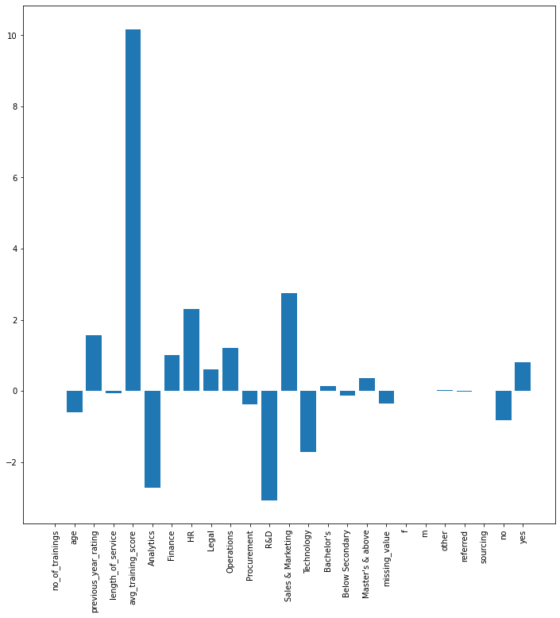

```python
from matplotlib import pyplot

# plot feature importance
plt.figure(figsize=(12, 12))
pyplot.bar(attributes,[x for x in list(importance[0])])
plt.xticks(rotation = 90)
pyplot.show()
```

## K Nearest Neighbour

```python
from sklearn.neighbors import KNeighborsClassifier

# define pipeline
model = KNeighborsClassifier()
over = SMOTE(sampling_strategy=0.2)
under = RandomUnderSampler(sampling_strategy=0.2)
steps = [ ('over', over), ('under',under),('model', model)]
pipeline = imbpipeline(steps=steps)



# defining parameter range
param_grid_KNN = {'model__n_neighbors': [1,5,7,10,20,30],
              }

grid_KNN = GridSearchCV(pipeline, param_grid_KNN, scoring=['accuracy','roc_auc','recall','precision','f1'],refit='precision', cv=cv,verbose = 3)

grid_KNN.fit(train_prepared, y_train)
```

```
Fitting 5 folds for each of 6 candidates, totalling 30 fits
[CV 1/5] END model__n_neighbors=1; accuracy: (test=0.880) f1: (test=0.312) precision: (test=0.308) recall: (test=0.316) roc_auc: (test=0.624) total time=  10.0s
[CV 2/5] END model__n_neighbors=1; accuracy: (test=0.882) f1: (test=0.313) precision: (test=0.315) recall: (test=0.311) roc_auc: (test=0.624) total time=   9.2s
[CV 3/5] END model__n_neighbors=1; accuracy: (test=0.880) f1: (test=0.292) precision: (test=0.296) recall: (test=0.287) roc_auc: (test=0.611) total time=   9.1s
[CV 4/5] END model__n_neighbors=1; accuracy: (test=0.879) f1: (test=0.273) precision: (test=0.283) recall: (test=0.264) roc_auc: (test=0.600) total time=   9.1s
[CV 5/5] END model__n_neighbors=1; accuracy: (test=0.879) f1: (test=0.309) precision: (test=0.304) recall: (test=0.314) roc_auc: (test=0.623) total time=   9.2s
[CV 1/5] END model__n_neighbors=5; accuracy: (test=0.893) f1: (test=0.310) precision: (test=0.350) recall: (test=0.278) roc_auc: (test=0.670) total time=  13.1s
[CV 2/5] END model__n_neighbors=5; accuracy: (test=0.895) f1: (test=0.296) precision: (test=0.350) recall: (test=0.257) roc_auc: (test=0.669) total time=  13.0s
[CV 3/5] END model__n_neighbors=5; accuracy: (test=0.897) f1: (test=0.306) precision: (test=0.364) recall: (test=0.264) roc_auc: (test=0.664) total time=  13.1s
[CV 4/5] END model__n_neighbors=5; accuracy: (test=0.893) f1: (test=0.299) precision: (test=0.344) recall: (test=0.265) roc_auc: (test=0.662) total time=  13.2s
[CV 5/5] END model__n_neighbors=5; accuracy: (test=0.895) f1: (test=0.330) precision: (test=0.368) recall: (test=0.299) roc_auc: (test=0.678) total time=  13.5s
[CV 1/5] END model__n_neighbors=7; accuracy: (test=0.897) f1: (test=0.303) precision: (test=0.363) recall: (test=0.260) roc_auc: (test=0.683) total time=  13.2s
[CV 2/5] END model__n_neighbors=7; accuracy: (test=0.902) f1: (test=0.306) precision: (test=0.390) recall: (test=0.251) roc_auc: (test=0.684) total time=  12.9s
[CV 3/5] END model__n_neighbors=7; accuracy: (test=0.904) f1: (test=0.308) precision: (test=0.408) recall: (test=0.247) roc_auc: (test=0.678) total time=  13.0s
[CV 4/5] END model__n_neighbors=7; accuracy: (test=0.902) f1: (test=0.305) precision: (test=0.390) recall: (test=0.250) roc_auc: (test=0.673) total time=  12.6s
[CV 5/5] END model__n_neighbors=7; accuracy: (test=0.900) f1: (test=0.324) precision: (test=0.390) recall: (test=0.277) roc_auc: (test=0.686) total time=  12.9s
[CV 1/5] END model__n_neighbors=10; accuracy: (test=0.909) f1: (test=0.288) precision: (test=0.442) recall: (test=0.214) roc_auc: (test=0.679) total time=  13.5s
[CV 2/5] END model__n_neighbors=10; accuracy: (test=0.913) f1: (test=0.300) precision: (test=0.487) recall: (test=0.216) roc_auc: (test=0.692) total time=  13.3s
[CV 3/5] END model__n_neighbors=10; accuracy: (test=0.912) f1: (test=0.287) precision: (test=0.473) recall: (test=0.206) roc_auc: (test=0.682) total time=  15.9s
[CV 4/5] END model__n_neighbors=10; accuracy: (test=0.912) f1: (test=0.284) precision: (test=0.474) recall: (test=0.203) roc_auc: (test=0.693) total time=  15.8s
[CV 5/5] END model__n_neighbors=10; accuracy: (test=0.914) f1: (test=0.330) precision: (test=0.506) recall: (test=0.244) roc_auc: (test=0.694) total time=  14.9s
[CV 1/5] END model__n_neighbors=20; accuracy: (test=0.915) f1: (test=0.281) precision: (test=0.511) recall: (test=0.194) roc_auc: (test=0.685) total time=  16.3s
[CV 2/5] END model__n_neighbors=20; accuracy: (test=0.917) f1: (test=0.265) precision: (test=0.553) recall: (test=0.174) roc_auc: (test=0.701) total time=  13.7s
[CV 3/5] END model__n_neighbors=20; accuracy: (test=0.916) f1: (test=0.263) precision: (test=0.539) recall: (test=0.174) roc_auc: (test=0.708) total time=  15.2s
[CV 4/5] END model__n_neighbors=20; accuracy: (test=0.915) f1: (test=0.269) precision: (test=0.520) recall: (test=0.182) roc_auc: (test=0.708) total time=  12.4s
[CV 5/5] END model__n_neighbors=20; accuracy: (test=0.918) f1: (test=0.317) precision: (test=0.556) recall: (test=0.222) roc_auc: (test=0.719) total time=  12.5s
[CV 1/5] END model__n_neighbors=30; accuracy: (test=0.915) f1: (test=0.261) precision: (test=0.514) recall: (test=0.175) roc_auc: (test=0.694) total time=  12.6s
[CV 2/5] END model__n_neighbors=30; accuracy: (test=0.916) f1: (test=0.246) precision: (test=0.545) recall: (test=0.159) roc_auc: (test=0.711) total time=  11.5s
[CV 3/5] END model__n_neighbors=30; accuracy: (test=0.917) f1: (test=0.257) precision: (test=0.569) recall: (test=0.166) roc_auc: (test=0.714) total time=  10.9s
[CV 4/5] END model__n_neighbors=30; accuracy: (test=0.916) f1: (test=0.260) precision: (test=0.537) recall: (test=0.172) roc_auc: (test=0.707) total time=  12.2s
[CV 5/5] END model__n_neighbors=30; accuracy: (test=0.920) f1: (test=0.298) precision: (test=0.616) recall: (test=0.197) roc_auc: (test=0.724) total time=  12.1s
```

```
GridSearchCV(cv=StratifiedKFold(n_splits=5, random_state=42, shuffle=True),
             estimator=Pipeline(steps=[('over', SMOTE(sampling_strategy=0.2)),
                                       ('under',
                                        RandomUnderSampler(sampling_strategy=0.2)),
                                       ('model', KNeighborsClassifier())]),
             param_grid={'model__n_neighbors': [1, 5, 7, 10, 20, 30]},
             refit='precision',
             scoring=['accuracy', 'roc_auc', 'recall', 'precision', 'f1'],
             verbose=3)
```

```python
# print best parameter after tuning
grid_KNN_best_parameters=grid_KNN.best_params_
print(grid_KNN_best_parameters)

# print best estimator after tuning
grid_KNN_best_estimator=grid_KNN.best_estimator_
print(grid_KNN_best_estimator)

# print grid search cross validation results
grid_KNN_res = grid_KNN.cv_results_
print(grid_KNN_res)
```

[output not shown]

```python
KNN_precision_mean= mean(grid_KNN_res["mean_test_precision"])
KNN_precision_mean
```

```
0.4355033890299396
```

```python
KNN_roc_auc_mean= mean(grid_KNN_res["mean_test_roc_auc"])
KNN_recall_mean= mean(grid_KNN_res["mean_test_recall"])
KNN_f1_mean= mean(grid_KNN_res["mean_test_f1"])
KNN_accuracy_mean= mean(grid_KNN_res["mean_test_accuracy"])
```

## Complement NB

```python
from sklearn.naive_bayes import ComplementNB

# define pipeline
model = ComplementNB()
steps = [('model', model)]
pipeline = Pipeline(steps=steps)

param_grid_CNB ={'model__alpha': [0.1,0.5,1,4,5,10,20]
              }


grid_CNB = GridSearchCV(pipeline, param_grid_CNB, scoring=['accuracy','roc_auc','recall','precision','f1'],refit='precision', cv=cv,verbose = 3)

grid_CNB.fit(train_prepared, y_train)
```

```
Fitting 5 folds for each of 7 candidates, totalling 35 fits
[CV 1/5] END model__alpha=0.1; accuracy: (test=0.642) f1: (test=0.197) precision: (test=0.122) recall: (test=0.510) roc_auc: (test=0.633) total time=   0.0s
[CV 2/5] END model__alpha=0.1; accuracy: (test=0.668) f1: (test=0.207) precision: (test=0.130) recall: (test=0.502) roc_auc: (test=0.650) total time=   0.0s
[CV 3/5] END model__alpha=0.1; accuracy: (test=0.682) f1: (test=0.236) precision: (test=0.149) recall: (test=0.569) roc_auc: (test=0.664) total time=   0.0s
[CV 4/5] END model__alpha=0.1; accuracy: (test=0.676) f1: (test=0.221) precision: (test=0.140) recall: (test=0.534) roc_auc: (test=0.661) total time=   0.0s
[CV 5/5] END model__alpha=0.1; accuracy: (test=0.648) f1: (test=0.217) precision: (test=0.134) recall: (test=0.566) roc_auc: (test=0.662) total time=   0.0s
[CV 1/5] END model__alpha=0.5; accuracy: (test=0.642) f1: (test=0.197) precision: (test=0.122) recall: (test=0.508) roc_auc: (test=0.633) total time=   0.0s
[CV 2/5] END model__alpha=0.5; accuracy: (test=0.668) f1: (test=0.207) precision: (test=0.130) recall: (test=0.502) roc_auc: (test=0.650) total time=   0.0s
[CV 3/5] END model__alpha=0.5; accuracy: (test=0.682) f1: (test=0.235) precision: (test=0.148) recall: (test=0.565) roc_auc: (test=0.664) total time=   0.0s
[CV 4/5] END model__alpha=0.5; accuracy: (test=0.676) f1: (test=0.221) precision: (test=0.139) recall: (test=0.532) roc_auc: (test=0.661) total time=   0.0s
[CV 5/5] END model__alpha=0.5; accuracy: (test=0.649) f1: (test=0.217) precision: (test=0.134) recall: (test=0.564) roc_auc: (test=0.662) total time=   0.0s
[CV 1/5] END model__alpha=1; accuracy: (test=0.643) f1: (test=0.197) precision: (test=0.122) recall: (test=0.507) roc_auc: (test=0.633) total time=   0.0s
[CV 2/5] END model__alpha=1; accuracy: (test=0.669) f1: (test=0.207) precision: (test=0.130) recall: (test=0.501) roc_auc: (test=0.650) total time=   0.0s
[CV 3/5] END model__alpha=1; accuracy: (test=0.682) f1: (test=0.233) precision: (test=0.147) recall: (test=0.561) roc_auc: (test=0.664) total time=   0.0s
[CV 4/5] END model__alpha=1; accuracy: (test=0.677) f1: (test=0.222) precision: (test=0.140) recall: (test=0.534) roc_auc: (test=0.661) total time=   0.0s
[CV 5/5] END model__alpha=1; accuracy: (test=0.649) f1: (test=0.217) precision: (test=0.134) recall: (test=0.564) roc_auc: (test=0.662) total time=   0.0s
[CV 1/5] END model__alpha=4; accuracy: (test=0.648) f1: (test=0.197) precision: (test=0.122) recall: (test=0.500) roc_auc: (test=0.633) total time=   0.0s
[CV 2/5] END model__alpha=4; accuracy: (test=0.671) f1: (test=0.204) precision: (test=0.129) recall: (test=0.490) roc_auc: (test=0.649) total time=   0.0s
[CV 3/5] END model__alpha=4; accuracy: (test=0.687) f1: (test=0.235) precision: (test=0.149) recall: (test=0.558) roc_auc: (test=0.665) total time=   0.0s
[CV 4/5] END model__alpha=4; accuracy: (test=0.682) f1: (test=0.227) precision: (test=0.143) recall: (test=0.541) roc_auc: (test=0.661) total time=   0.0s
[CV 5/5] END model__alpha=4; accuracy: (test=0.652) f1: (test=0.218) precision: (test=0.135) recall: (test=0.563) roc_auc: (test=0.661) total time=   0.0s
[CV 1/5] END model__alpha=5; accuracy: (test=0.649) f1: (test=0.197) precision: (test=0.123) recall: (test=0.499) roc_auc: (test=0.634) total time=   0.0s
[CV 2/5] END model__alpha=5; accuracy: (test=0.672) f1: (test=0.204) precision: (test=0.129) recall: (test=0.488) roc_auc: (test=0.649) total time=   0.0s
[CV 3/5] END model__alpha=5; accuracy: (test=0.688) f1: (test=0.236) precision: (test=0.149) recall: (test=0.556) roc_auc: (test=0.665) total time=   0.0s
[CV 4/5] END model__alpha=5; accuracy: (test=0.683) f1: (test=0.226) precision: (test=0.143) recall: (test=0.536) roc_auc: (test=0.661) total time=   0.0s
[CV 5/5] END model__alpha=5; accuracy: (test=0.652) f1: (test=0.218) precision: (test=0.135) recall: (test=0.561) roc_auc: (test=0.661) total time=   0.0s
[CV 1/5] END model__alpha=10; accuracy: (test=0.653) f1: (test=0.197) precision: (test=0.123) recall: (test=0.493) roc_auc: (test=0.634) total time=   0.0s
[CV 2/5] END model__alpha=10; accuracy: (test=0.679) f1: (test=0.207) precision: (test=0.132) recall: (test=0.485) roc_auc: (test=0.647) total time=   0.0s
[CV 3/5] END model__alpha=10; accuracy: (test=0.692) f1: (test=0.232) precision: (test=0.148) recall: (test=0.540) roc_auc: (test=0.665) total time=   0.0s
[CV 4/5] END model__alpha=10; accuracy: (test=0.691) f1: (test=0.228) precision: (test=0.145) recall: (test=0.529) roc_auc: (test=0.660) total time=   0.0s
[CV 5/5] END model__alpha=10; accuracy: (test=0.660) f1: (test=0.221) precision: (test=0.137) recall: (test=0.559) roc_auc: (test=0.660) total time=   0.0s
[CV 1/5] END model__alpha=20; accuracy: (test=0.666) f1: (test=0.201) precision: (test=0.127) recall: (test=0.489) roc_auc: (test=0.634) total time=   0.0s
[CV 2/5] END model__alpha=20; accuracy: (test=0.689) f1: (test=0.210) precision: (test=0.134) recall: (test=0.478) roc_auc: (test=0.643) total time=   0.0s
[CV 3/5] END model__alpha=20; accuracy: (test=0.701) f1: (test=0.232) precision: (test=0.149) recall: (test=0.524) roc_auc: (test=0.663) total time=   0.0s
[CV 4/5] END model__alpha=20; accuracy: (test=0.697) f1: (test=0.224) precision: (test=0.143) recall: (test=0.507) roc_auc: (test=0.656) total time=   0.0s
[CV 5/5] END model__alpha=20; accuracy: (test=0.672) f1: (test=0.225) precision: (test=0.141) recall: (test=0.554) roc_auc: (test=0.658) total time=   0.0s
```

```
GridSearchCV(cv=StratifiedKFold(n_splits=5, random_state=42, shuffle=True),
             estimator=Pipeline(steps=[('model', ComplementNB())]),
             param_grid={'model__alpha': [0.1, 0.5, 1, 4, 5, 10, 20]},
             refit='precision',
             scoring=['accuracy', 'roc_auc', 'recall', 'precision', 'f1'],
             verbose=3)
```

```python
# print best parameter after tuning
grid_CNB_best_parameters=grid_CNB.best_params_
print(grid_CNB_best_parameters)

# print best estimator after tuning
grid_CNB_best_estimator=grid_CNB.best_estimator_
print(grid_CNB_best_estimator)

# print grid search cross validation results
grid_CNB_res = grid_CNB.cv_results_
print(grid_CNB_res)
```

[output not shown]

```python
CNB_precision_mean= mean(grid_CNB_res["mean_test_precision"])
CNB_precision_mean
```

```
0.13603668197135824
```

```python
CNB_roc_auc_mean= mean(grid_CNB_res["mean_test_roc_auc"])
CNB_recall_mean= mean(grid_CNB_res["mean_test_recall"])
CNB_f1_mean= mean(grid_CNB_res["mean_test_f1"])
CNB_accuracy_mean= mean(grid_CNB_res["mean_test_accuracy"])
```

## Linear Support Vector Classification

```python
from sklearn.svm import LinearSVC

# define pipeline
model = LinearSVC()
over = SMOTE(sampling_strategy=0.2)
under = RandomUnderSampler(sampling_strategy=0.2)
steps = [ ('over', over), ('under',under),('model', model)]
pipeline = imbpipeline(steps=steps)


param_grid_SVC ={'model__C': [0.1,0.2,0.5,1,3,5],
                 'model__random_state': [42],
                 'model__max_iter':[10000,20000],
              }


# fitting the model for grid search
grid_SVC = GridSearchCV(pipeline, param_grid_SVC, scoring=['accuracy','roc_auc','recall','precision','f1'],refit='precision', cv=cv,verbose = 3)

grid_SVC.fit(train_prepared, y_train)
```

[output not shown]

[output cut: 35 more lines]

```
GridSearchCV(cv=StratifiedKFold(n_splits=5, random_state=42, shuffle=True),
             estimator=Pipeline(steps=[('over', SMOTE(sampling_strategy=0.2)),
                                       ('under',
                                        RandomUnderSampler(sampling_strategy=0.2)),
                                       ('model', LinearSVC())]),
             param_grid={'model__C': [0.1, 0.2, 0.5, 1, 3, 5],
                         'model__max_iter': [10000, 20000],
                         'model__random_state': [42]},
             refit='precision',
             scoring=['accuracy', 'roc_auc', 'recall', 'precision', 'f1'],
             verbose=3)
```

```python
# print best parameter after tuning
grid_SVC_best_parameters=grid_SVC.best_params_
print(grid_SVC_best_parameters)

# print best estimator after tuning
grid_SVC_best_estimator=grid_SVC.best_estimator_
print(grid_SVC_best_estimator)

# print grid search cross validation results
grid_SVC_res = grid_SVC.cv_results_
print(grid_SVC_res)
```

[output not shown]

[output cut: 41 more lines]

[output not shown]

```python
SVC_precision_mean= mean(grid_SVC_res["mean_test_precision"])
SVC_precision_mean
```

```
0.8967018974316877
```

```python
SVC_roc_auc_mean= mean(grid_SVC_res["mean_test_roc_auc"])
SVC_recall_mean= mean(grid_SVC_res["mean_test_recall"])
SVC_f1_mean= mean(grid_SVC_res["mean_test_f1"])
SVC_accuracy_mean= mean(grid_SVC_res["mean_test_accuracy"])
```

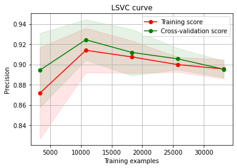

```python
# Logistic REgression - Learning Curve
plot_learning_curve(estimator = grid_SVC.best_estimator_,title = "LSVC curve",
                    X = train_prepared, y = y_train, cv = cv);
```

## Decision Tree

```python
from sklearn.tree import DecisionTreeClassifier


# define pipeline
model = DecisionTreeClassifier()
over = SMOTE(sampling_strategy=0.2)
under = RandomUnderSampler(sampling_strategy=0.2)
steps = [ ('over', over), ('under',under),('model', model)]
pipeline = imbpipeline(steps=steps)

# defining parameter range
param_grid_DTC = {
    'model__min_samples_leaf': [2,3,4,5],
    'model__max_depth' : [4,5,6,8],
     'model__random_state': [42],
    }

# fitting the model for grid search
grid_DTC = GridSearchCV(pipeline, param_grid_DTC, scoring=['accuracy','roc_auc','recall','precision','f1'],refit='precision', cv=cv,verbose = 3)

grid_DTC.fit(train_prepared, y_train)
```

[output not shown]

[output cut: 55 more lines]

```
GridSearchCV(cv=StratifiedKFold(n_splits=5, random_state=42, shuffle=True),
             estimator=Pipeline(steps=[('over', SMOTE(sampling_strategy=0.2)),
                                       ('under',
                                        RandomUnderSampler(sampling_strategy=0.2)),
                                       ('model', DecisionTreeClassifier())]),
             param_grid={'model__max_depth': [4, 5, 6, 8],
                         'model__min_samples_leaf': [2, 3, 4, 5],
                         'model__random_state': [42]},
             refit='precision',
             scoring=['accuracy', 'roc_auc', 'recall', 'precision', 'f1'],
             verbose=3)
```

```python
# print best parameter after tuning
grid_DTC_best_parameters=grid_DTC.best_params_
print(grid_DTC_best_parameters)

# print best estimator after tuning
grid_DTC_best_estimator=grid_DTC.best_estimator_
print(grid_DTC_best_estimator)

# print grid search cross validation results
grid_DTC_res = grid_DTC.cv_results_
print(grid_DTC_res)
```

[output not shown]

[output cut: 82 more lines]

[output not shown]

```python
DTC_precision_mean= mean(grid_DTC_res["mean_test_precision"])
DTC_precision_mean
```

```
0.7679031655626041
```

```python
DTC_roc_auc_mean= mean(grid_DTC_res["mean_test_roc_auc"])
DTC_recall_mean= mean(grid_DTC_res["mean_test_recall"])
DTC_f1_mean= mean(grid_DTC_res["mean_test_f1"])
DTC_accuracy_mean= mean(grid_DTC_res["mean_test_accuracy"])
```

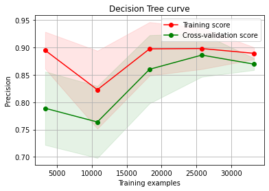

```python
# Decision Tree - Learning Curve
plot_learning_curve(estimator = grid_DTC.best_estimator_,title = "Decision Tree curve",
                    X = train_prepared, y = y_train, cv = cv);
```

## Random Forest

```python
from sklearn.ensemble import RandomForestClassifier

# define pipeline
model = RandomForestClassifier()
over = SMOTE(sampling_strategy=0.2)
under = RandomUnderSampler(sampling_strategy=0.2)
steps = [ ('over', over), ('under',under),('model', model)]
pipeline = imbpipeline(steps=steps)

# defining parameter range
param_grid_RFR = {
        'model__n_estimators': [100,250,500,1000],
    'model__min_samples_leaf': [2,3,4],
    'model__max_depth' : [4,6,8],
     'model__random_state': [42],
    }

# fitting the model for grid search
grid_RF = GridSearchCV(pipeline, param_grid_RFR, scoring=['accuracy','roc_auc','recall','precision','f1'],refit='precision', cv=cv,verbose = 3)

grid_RF.fit(train_prepared, y_train)
```

[output not shown]

[output cut: 155 more lines]

```
GridSearchCV(cv=StratifiedKFold(n_splits=5, random_state=42, shuffle=True),
             estimator=Pipeline(steps=[('over', SMOTE(sampling_strategy=0.2)),
                                       ('under',
                                        RandomUnderSampler(sampling_strategy=0.2)),
                                       ('model', RandomForestClassifier())]),
             param_grid={'model__max_depth': [4, 6, 8],
                         'model__min_samples_leaf': [2, 3, 4],
                         'model__n_estimators': [100, 250, 500, 1000],
                         'model__random_state': [42]},
             refit='precision',
             scoring=['accuracy', 'roc_auc', 'recall', 'precision', 'f1'],
             verbose=3)
```

```python
# print best parameter after tuning
grid_RF_best_parameters=grid_RF.best_params_
print(grid_RF_best_parameters)

# print best estimator after tuning
grid_RF_best_estimator=grid_RF.best_estimator_
print(grid_RF_best_estimator)

# print grid search cross validation results
grid_RF_res = grid_RF.cv_results_
print(grid_RF_res)
```

[output not shown]

[output cut: 270 more lines]

[output not shown]

```python
RFC_precision_mean= mean(grid_RF_res["mean_test_precision"])
RFC_precision_mean
```

```
0.800932245462425
```

```python
RFC_roc_auc_mean= mean(grid_RF_res["mean_test_roc_auc"])
RFC_recall_mean= mean(grid_RF_res["mean_test_recall"])
RFC_f1_mean= mean(grid_RF_res["mean_test_f1"])
RFC_accuracy_mean= mean(grid_RF_res["mean_test_accuracy"])
```

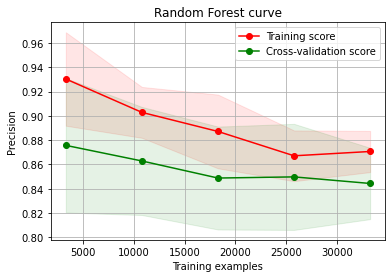

```python
# Random Forest - Learning Curve
plot_learning_curve(estimator = grid_RF.best_estimator_,title = "Random Forest curve",
                    X = train_prepared, y = y_train, cv = cv);
```

## GradientBoostingClassifier

```python
from sklearn.ensemble import GradientBoostingClassifier

# define pipeline
model = GradientBoostingClassifier()

# defining parameter range
param_grid_GBC = {
        'n_estimators': [100,200,300],
    'min_samples_leaf': [2,3,4],
    'max_depth' : [4,6],
     'random_state': [42],
    }

# fitting the model for grid search
grid_GBC = GridSearchCV(model, param_grid_GBC, scoring=['accuracy','roc_auc','recall','precision','f1'],refit='precision', cv=cv,verbose = 3)

grid_GBC.fit(train_prepared, y_train)
```

[output not shown]

[output cut: 65 more lines]

```
GridSearchCV(cv=StratifiedKFold(n_splits=5, random_state=42, shuffle=True),
             estimator=GradientBoostingClassifier(),
             param_grid={'max_depth': [4, 6], 'min_samples_leaf': [2, 3, 4],
                         'n_estimators': [100, 200, 300],
                         'random_state': [42]},
             refit='precision',
             scoring=['accuracy', 'roc_auc', 'recall', 'precision', 'f1'],
             verbose=3)
```

```python
# print best parameter after tuning
grid_GBC_best_parameters=grid_GBC.best_params_
print(grid_GBC_best_parameters)

# print best estimator after tuning
grid_GBC_best_estimator=grid_GBC.best_estimator_
print(grid_GBC_best_estimator)

# print grid search cross validation results
grid_GBC_res = grid_GBC.cv_results_
print(grid_GBC_res)
```

[output not shown]

[output cut: 92 more lines]

[output not shown]

```python
GBC_precision_mean= mean(grid_GBC_res["mean_test_precision"])
GBC_precision_mean
```

```
0.9156594939764628
```

```python
GBC_roc_auc_mean= mean(grid_GBC_res["mean_test_roc_auc"])
GBC_recall_mean= mean(grid_GBC_res["mean_test_recall"])
GBC_f1_mean= mean(grid_GBC_res["mean_test_f1"])
GBC_accuracy_mean= mean(grid_GBC_res["mean_test_accuracy"])
```

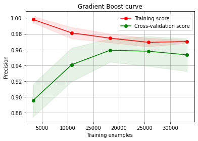

```python
# Gradient Boost- Learning Curve
plot_learning_curve(estimator = grid_GBC.best_estimator_,title = "Gradient Boost curve",
                    X = train_prepared, y = y_train, cv = cv);
```

```python
importance = grid_GBC_best_estimator.feature_importances_
importance
```

```
array([0.00000000e+00, 1.17362922e-02, 5.88097127e-02, 5.31956036e-03,
       5.10330056e-01, 5.11350705e-02, 1.92747277e-02, 7.52896244e-03,
       1.71974350e-03, 9.19412635e-02, 4.66129190e-02, 2.62786198e-02,
       7.79117752e-02, 1.86665062e-02, 6.32865831e-04, 4.86083345e-04,
       1.39698395e-03, 5.56072759e-04, 1.09978733e-03, 1.32601857e-03,
       6.23811446e-04, 9.69306309e-04, 6.39172729e-04, 2.27282216e-02,
       4.22764668e-02])
```

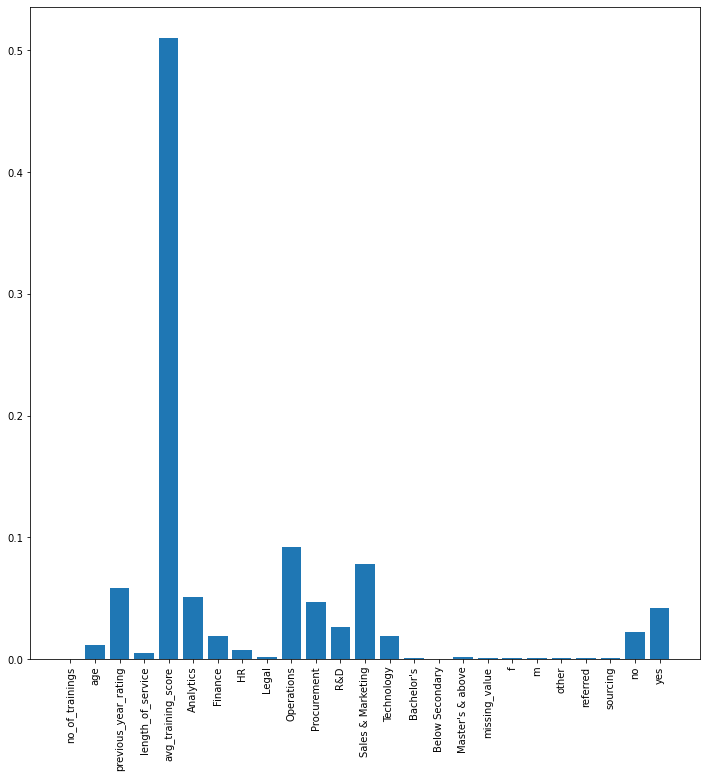

```python
from matplotlib import pyplot

# plot feature importance
plt.figure(figsize=(12, 12))
plt.xticks(rotation = 90)
pyplot.bar(attributes, importance)
pyplot.show()
```

As obtained before for the logistic coefficients importance, the average trainign score is still the most important factor in determining if an employee will be promoted or not.

## Balanced Bagging Classifier

```python
from imblearn.ensemble import BalancedBaggingClassifier

model = BalancedBaggingClassifier()

param_grid_BRFC  = {
        'n_estimators': [100,250,500,1000],
    'bootstrap':['True'],
    'sampling_strategy':['not majority'],
     'random_state': [42],
    }

# fitting the model for grid search
grid_BBC = GridSearchCV(model, param_grid_BRFC, scoring=['accuracy','roc_auc','recall','precision','f1'],refit='precision', cv=cv,verbose = 3)

grid_BBC.fit(train_prepared, y_train)
```

[output not shown]

```
GridSearchCV(cv=StratifiedKFold(n_splits=5, random_state=42, shuffle=True),
             estimator=BalancedBaggingClassifier(),
             param_grid={'bootstrap': ['True'],
                         'n_estimators': [100, 250, 500, 1000],
                         'random_state': [42],
                         'sampling_strategy': ['not majority']},
             refit='precision',
             scoring=['accuracy', 'roc_auc', 'recall', 'precision', 'f1'],
             verbose=3)
```

```python
# print best parameter after tuning
grid_BBC_best_parameters=grid_BBC.best_params_
print(grid_BBC_best_parameters)

# print best estimator after tuning
grid_BBC_best_estimator=grid_BBC.best_estimator_
print(grid_BBC_best_estimator)

# print grid search cross validation results
grid_BBC_res = grid_BBC.cv_results_
print(grid_BBC_res)
```

[output not shown]

```python
BBC_precision_mean= mean(grid_BBC_res["mean_test_precision"])
BBC_precision_mean
```

```
0.6779379543652353
```

```python
BBC_roc_auc_mean= mean(grid_BBC_res["mean_test_roc_auc"])
BBC_recall_mean= mean(grid_BBC_res["mean_test_recall"])
BBC_f1_mean= mean(grid_BBC_res["mean_test_f1"])
BBC_accuracy_mean= mean(grid_BBC_res["mean_test_accuracy"])
```

```python
pd.DataFrame([['Logistic Regression', LR_precision_mean,LR_roc_auc_mean,LR_recall_mean,LR_f1_mean,LR_accuracy_mean],
             ['KNN', KNN_precision_mean,KNN_roc_auc_mean,KNN_recall_mean,KNN_f1_mean,KNN_accuracy_mean],
             ['Compliment NB', CNB_precision_mean,CNB_roc_auc_mean,CNB_recall_mean,CNB_f1_mean,CNB_accuracy_mean],
             ['Linear SVC', SVC_precision_mean,SVC_roc_auc_mean,SVC_recall_mean,SVC_f1_mean,SVC_accuracy_mean],
             ['Decision Tree Classifier', DTC_precision_mean,DTC_roc_auc_mean,DTC_recall_mean,DTC_f1_mean,DTC_accuracy_mean],
             ['Random Forest Classifier', RFC_precision_mean,RFC_roc_auc_mean,RFC_recall_mean,RFC_f1_mean,RFC_accuracy_mean],
             ['Gradient Boost Classifier', GBC_precision_mean,GBC_roc_auc_mean,GBC_recall_mean,GBC_f1_mean,GBC_accuracy_mean],
             ['Balanced Bagging Classifier ',BBC_precision_mean,BBC_roc_auc_mean,BBC_recall_mean,BBC_f1_mean,BBC_accuracy_mean]],


             columns=['Model', 'Precision','ROC_AUC', 'RECALL','F1','ACCURACY'],)
```

[output not shown]

Based on the above summary table, we can clearly say that the Gradinet Boost classifier showed the highest metrics among all other models especially in terms of precision, which is the main metric adopted in our work for evaluation.

# Evaluation on the Test Data

Although, the Gradient Boost Classifier was the most impressive model we can adopt, however we will run all the models again on our test data to see how the performance is impacted in each one.

```python
X_test = test.drop("is_promoted", axis=1)
y_test = test["is_promoted"].copy()

X_test_prepared = full_pipeline.transform(X_test)
```

```python
from sklearn.metrics import precision_score
from sklearn.metrics import roc_auc_score
from sklearn.metrics import recall_score
from sklearn.metrics import f1_score
from sklearn.metrics import accuracy_score
```

1- Logistic Regression

```python
LR_final_model = grid_LR_best_estimator

LR_final_predictions = LR_final_model.predict(X_test_prepared)

LR_test_precision = precision_score(y_test, LR_final_predictions)
LR_test_roc_auc = roc_auc_score(y_test, LR_final_predictions)
LR_test_recall = recall_score(y_test, LR_final_predictions)
LR_test_f1 = f1_score(y_test, LR_final_predictions)
LR_test_accuracy = accuracy_score(y_test, LR_final_predictions)

pd.DataFrame([['Logistic Regression', LR_test_precision,LR_test_roc_auc,LR_test_recall,LR_test_f1,LR_test_accuracy]],
             columns=['Model', 'Test Precision','Test ROC_AUC', 'Test RECALL','Test F1','Test ACCURACY'],)
```

|  | Model | Test Precision | Test ROC_AUC | Test RECALL | Test F1 | Test ACCURACY |
| --- | --- | --- | --- | --- | --- | --- |
| 0 | Logistic Regression | 0.857627 | 0.639129 | 0.282682 | 0.42521 | 0.934174 |

```python
from sklearn.metrics import classification_report

print(f"Classifier Report : \n\n {classification_report(y_test, LR_final_predictions)}")
```

```
Classifier Report :

               precision    recall  f1-score   support

           0       0.94      1.00      0.97      9496
           1       0.86      0.28      0.43       895

    accuracy                           0.93     10391
   macro avg       0.90      0.64      0.70     10391
weighted avg       0.93      0.93      0.92     10391
```

2- KNN

```python
KNN_final_model = grid_KNN_best_estimator

KNN_final_predictions = KNN_final_model.predict(X_test_prepared)

KNN_test_precision = precision_score(y_test, KNN_final_predictions)
KNN_test_roc_auc = roc_auc_score(y_test, KNN_final_predictions)
KNN_test_recall = recall_score(y_test, KNN_final_predictions)
KNN_test_f1 = f1_score(y_test, KNN_final_predictions)
KNN_test_accuracy = accuracy_score(y_test, KNN_final_predictions)

pd.DataFrame([['KNN', KNN_test_precision,KNN_test_roc_auc,KNN_test_recall,KNN_test_f1,KNN_test_accuracy]],
             columns=['Model', 'Test Precision','Test ROC_AUC', 'Test RECALL','Test F1','Test ACCURACY'],)
```

|  | Model | Test Precision | Test ROC_AUC | Test RECALL | Test F1 | Test ACCURACY |
| --- | --- | --- | --- | --- | --- | --- |
| 0 | KNN | 0.605364 | 0.582845 | 0.176536 | 0.273356 | 0.919161 |

```python
print(f"Classifier Report : \n\n {classification_report(y_test, KNN_final_predictions)}")
```

```
Classifier Report :

               precision    recall  f1-score   support

           0       0.93      0.99      0.96      9496
           1       0.61      0.18      0.27       895

    accuracy                           0.92     10391
   macro avg       0.77      0.58      0.62     10391
weighted avg       0.90      0.92      0.90     10391
```

```python
CNB_final_model = grid_CNB_best_estimator

CNB_final_predictions = CNB_final_model.predict(X_test_prepared)

CNB_test_precision = precision_score(y_test, CNB_final_predictions)
CNB_test_roc_auc = roc_auc_score(y_test, CNB_final_predictions)
CNB_test_recall = recall_score(y_test, CNB_final_predictions)
CNB_test_f1 = f1_score(y_test, CNB_final_predictions)
CNB_test_accuracy = accuracy_score(y_test, CNB_final_predictions)

pd.DataFrame([['Compliment NB', CNB_test_precision,CNB_test_roc_auc,CNB_test_recall,CNB_test_f1,CNB_test_accuracy]],
             columns=['Model', 'Test Precision','Test ROC_AUC', 'Test RECALL','Test F1','Test ACCURACY'],)
```

|  | Model | Test Precision | Test ROC_AUC | Test RECALL | Test F1 | Test ACCURACY |
| --- | --- | --- | --- | --- | --- | --- |
| 0 | Compliment NB | 0.14217 | 0.613972 | 0.528492 | 0.224064 | 0.684727 |

```python
print(f"Classifier Report : \n\n {classification_report(y_test, CNB_final_predictions)}")
```

```
Classifier Report :

               precision    recall  f1-score   support

           0       0.94      0.70      0.80      9496
           1       0.14      0.53      0.22       895

    accuracy                           0.68     10391
   macro avg       0.54      0.61      0.51     10391
weighted avg       0.87      0.68      0.75     10391
```

4- Linear Support Vector Classification

```python
LSVC_final_model = grid_SVC_best_estimator

LSCV_final_predictions = LSVC_final_model.predict(X_test_prepared)

LSCV_test_precision = precision_score(y_test, LSCV_final_predictions)
LSCV_test_roc_auc = roc_auc_score(y_test, LSCV_final_predictions)
LSCV_test_recall = recall_score(y_test, LSCV_final_predictions)
LSCV_test_f1 = f1_score(y_test, LSCV_final_predictions)
LSCV_test_accuracy = accuracy_score(y_test, LSCV_final_predictions)

pd.DataFrame([['Linear SVC', LSCV_test_precision,LSCV_test_roc_auc,LSCV_test_recall,LSCV_test_f1,LSCV_test_accuracy]],
             columns=['Model', 'Test Precision','Test ROC_AUC', 'Test RECALL','Test F1','Test ACCURACY'],)
```

|  | Model | Test Precision | Test ROC_AUC | Test RECALL | Test F1 | Test ACCURACY |
| --- | --- | --- | --- | --- | --- | --- |
| 0 | Linear SVC | 0.886364 | 0.650671 | 0.305028 | 0.453865 | 0.936772 |

```python
print(f"Classifier Report : \n\n {classification_report(y_test, LSCV_final_predictions)}")
```

```
Classifier Report :

               precision    recall  f1-score   support

           0       0.94      1.00      0.97      9496
           1       0.89      0.31      0.45       895

    accuracy                           0.94     10391
   macro avg       0.91      0.65      0.71     10391
weighted avg       0.93      0.94      0.92     10391
```

5- Decision Tree

```python
DTC_final_model = grid_DTC_best_estimator

DTC_final_predictions = DTC_final_model.predict(X_test_prepared)

DTC_test_precision = precision_score(y_test, DTC_final_predictions)
DTC_test_roc_auc = roc_auc_score(y_test, DTC_final_predictions)
DTC_test_recall = recall_score(y_test, DTC_final_predictions)
DTC_test_f1 = f1_score(y_test, DTC_final_predictions)
DTC_test_accuracy = accuracy_score(y_test, DTC_final_predictions)

pd.DataFrame([['Decision Tree Classifier', DTC_test_precision,DTC_test_roc_auc,DTC_test_recall,DTC_test_f1,DTC_test_accuracy]],
            columns=['Model', 'Test Precision','Test ROC_AUC', 'Test RECALL','Test F1','Test ACCURACY'],)
```

|  | Model | Test Precision | Test ROC_AUC | Test RECALL | Test F1 | Test ACCURACY |
| --- | --- | --- | --- | --- | --- | --- |
| 0 | Decision Tree Classifier | 0.875 | 0.619597 | 0.242458 | 0.379703 | 0.931768 |

```python
print(f"Classifier Report : \n\n {classification_report(y_test, DTC_final_predictions)}")
```

```
Classifier Report :

               precision    recall  f1-score   support

           0       0.93      1.00      0.96      9496
           1       0.88      0.24      0.38       895

    accuracy                           0.93     10391
   macro avg       0.90      0.62      0.67     10391
weighted avg       0.93      0.93      0.91     10391
```

6- Random Forest

```python
RF_final_model = grid_RF_best_estimator

RF_final_predictions = RF_final_model.predict(X_test_prepared)

RF_test_precision = precision_score(y_test, RF_final_predictions)
RF_test_roc_auc = roc_auc_score(y_test, RF_final_predictions)
RF_test_recall = recall_score(y_test, RF_final_predictions)
RF_test_f1 = f1_score(y_test, RF_final_predictions)
RF_test_accuracy = accuracy_score(y_test, RF_final_predictions)

pd.DataFrame([ ['Random Forest Classifier', RF_test_precision,RF_test_roc_auc,RF_test_recall,RF_test_f1,RF_test_accuracy],],
             columns=['Model', 'Test Precision','Test ROC_AUC', 'Test RECALL','Test F1','Test ACCURACY'],)
```

|  | Model | Test Precision | Test ROC_AUC | Test RECALL | Test F1 | Test ACCURACY |
| --- | --- | --- | --- | --- | --- | --- |
| 0 | Random Forest Classifier | 0.8 | 0.565459 | 0.134078 | 0.229665 | 0.922529 |

```python
print(f"Classifier Report : \n\n {classification_report(y_test, RF_final_predictions)}")
```

```
Classifier Report :

               precision    recall  f1-score   support

           0       0.92      1.00      0.96      9496
           1       0.80      0.13      0.23       895

    accuracy                           0.92     10391
   macro avg       0.86      0.57      0.59     10391
weighted avg       0.91      0.92      0.90     10391
```

7- Gradient Boosting Classifier

```python
GBC_final_model = grid_GBC_best_estimator

GBC_final_predictions = GBC_final_model.predict(X_test_prepared)

GBC_test_precision = precision_score(y_test, GBC_final_predictions)
GBC_test_roc_auc = roc_auc_score(y_test, GBC_final_predictions)
GBC_test_recall = recall_score(y_test, GBC_final_predictions)
GBC_test_f1 = f1_score(y_test, GBC_final_predictions)
GBC_test_accuracy = accuracy_score(y_test, GBC_final_predictions)

pd.DataFrame([['Gradient Boosting Classifier', GBC_test_precision,GBC_test_roc_auc,GBC_test_recall,GBC_test_f1,GBC_test_accuracy],],
              columns=['Model', 'Test Precision','Test ROC_AUC', 'Test RECALL','Test F1','Test ACCURACY'],)
```

|  | Model | Test Precision | Test ROC_AUC | Test RECALL | Test F1 | Test ACCURACY |
| --- | --- | --- | --- | --- | --- | --- |
| 0 | Gradient Boosting Classifier | 0.944625 | 0.661116 | 0.324022 | 0.482529 | 0.940141 |

```python
print(f"Classifier Report : \n\n {classification_report(y_test, GBC_final_predictions)}")
```

```
Classifier Report :

               precision    recall  f1-score   support

           0       0.94      1.00      0.97      9496
           1       0.94      0.32      0.48       895

    accuracy                           0.94     10391
   macro avg       0.94      0.66      0.73     10391
weighted avg       0.94      0.94      0.93     10391
```

8- Balanced Bagging Classifier

```python
BBC_final_model = grid_BBC_best_estimator

BBC_final_predictions = BBC_final_model.predict(X_test_prepared)

BBC_test_precision = precision_score(y_test, BBC_final_predictions)
BBC_test_roc_auc = roc_auc_score(y_test, BBC_final_predictions)
BBC_test_recall = recall_score(y_test, BBC_final_predictions)
BBC_test_f1 = f1_score(y_test, BBC_final_predictions)
BBC_test_accuracy = accuracy_score(y_test, BBC_final_predictions)

pd.DataFrame([['Balanced Bagging Classifier ',BBC_test_precision,BBC_test_roc_auc,BBC_test_recall,BBC_test_f1,BBC_test_accuracy]],
             columns=['Model', 'Test Precision','Test ROC_AUC', 'Test RECALL','Test F1','Test ACCURACY'],)
```

|  | Model | Test Precision | Test ROC_AUC | Test RECALL | Test F1 | Test ACCURACY |
| --- | --- | --- | --- | --- | --- | --- |
| 0 | Balanced Bagging Classifier | 0.66242 | 0.66593 | 0.348603 | 0.456808 | 0.928592 |

```python
print(f"Classifier Report : \n\n {classification_report(y_test, BBC_final_predictions)}")
```

```
Classifier Report :

               precision    recall  f1-score   support

           0       0.94      0.98      0.96      9496
           1       0.66      0.35      0.46       895

    accuracy                           0.93     10391
   macro avg       0.80      0.67      0.71     10391
weighted avg       0.92      0.93      0.92     10391
```

```python
pd.DataFrame([['Logistic Regression', LR_test_precision,LR_test_roc_auc,LR_test_recall,LR_test_f1,LR_test_accuracy],
             ['KNN', KNN_test_precision,KNN_test_roc_auc,KNN_test_recall,KNN_test_f1,KNN_test_accuracy],
             ['Compliment NB', CNB_test_precision,CNB_test_roc_auc,CNB_test_recall,CNB_test_f1,CNB_test_accuracy],
             ['Linear SVC', LSCV_test_precision,LSCV_test_roc_auc,LSCV_test_recall,LSCV_test_f1,LSCV_test_accuracy],
             ['Decision Tree Classifier', DTC_test_precision,DTC_test_roc_auc,DTC_test_recall,DTC_test_f1,DTC_test_accuracy],
             ['Random Forest Classifier', RF_test_precision,RF_test_roc_auc,RF_test_recall,RF_test_f1,RF_test_accuracy],
             ['Gradient Boost Classifier', GBC_test_precision,GBC_test_roc_auc,GBC_test_recall,GBC_test_f1,GBC_test_accuracy],
             ['Balanced Bagging Classifier ',BBC_test_precision,BBC_test_roc_auc,BBC_test_recall,BBC_test_f1,BBC_test_accuracy]],


             columns=['Model', 'Precision','ROC_AUC', 'RECALL','F1','ACCURACY'],)
```

|  | Model | Precision | ROC_AUC | RECALL | F1 | ACCURACY |
| --- | --- | --- | --- | --- | --- | --- |
| 0 | Logistic Regression | 0.857627 | 0.639129 | 0.282682 | 0.425210 | 0.934174 |
| 1 | KNN | 0.605364 | 0.582845 | 0.176536 | 0.273356 | 0.919161 |
| 2 | Compliment NB | 0.142170 | 0.613972 | 0.528492 | 0.224064 | 0.684727 |
| 3 | Linear SVC | 0.886364 | 0.650671 | 0.305028 | 0.453865 | 0.936772 |
| 4 | Decision Tree Classifier | 0.875000 | 0.619597 | 0.242458 | 0.379703 | 0.931768 |
| 5 | Random Forest Classifier | 0.800000 | 0.565459 | 0.134078 | 0.229665 | 0.922529 |
| 6 | Gradient Boost Classifier | 0.944625 | 0.661116 | 0.324022 | 0.482529 | 0.940141 |
| 7 | Balanced Bagging Classifier | 0.662420 | 0.665930 | 0.348603 | 0.456808 | 0.928592 |

### precision-recall curve for all models

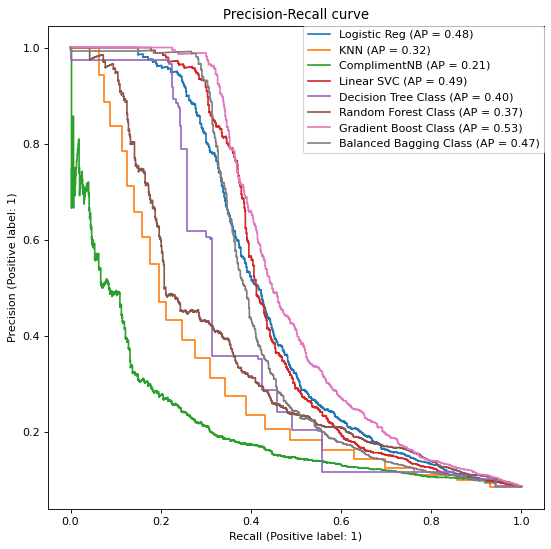

```python
from sklearn.metrics import precision_recall_curve
from sklearn.metrics import plot_precision_recall_curve
import matplotlib.pyplot as plt
plt.figure(figsize=(8, 8), dpi=80)

plot_precision_recall_curve(LR_final_model, X_test_prepared, y_test, ax = plt.gca(),name = "Logistic Reg")
plot_precision_recall_curve(KNN_final_model, X_test_prepared, y_test, ax = plt.gca(),name = "KNN")
plot_precision_recall_curve(CNB_final_model, X_test_prepared, y_test, ax = plt.gca(),name = "ComplimentNB")
plot_precision_recall_curve(LSVC_final_model, X_test_prepared, y_test, ax = plt.gca(),name = "Linear SVC")
plot_precision_recall_curve(DTC_final_model, X_test_prepared, y_test, ax = plt.gca(),name = "Decision Tree Class")
plot_precision_recall_curve(RF_final_model, X_test_prepared, y_test, ax = plt.gca(),name = "Random Forest Class")
plot_precision_recall_curve(GBC_final_model, X_test_prepared, y_test, ax = plt.gca(),name = "Gradient Boost Class")
plot_precision_recall_curve(BBC_final_model, X_test_prepared, y_test, ax = plt.gca(),name = "Balanced Bagging Class")
plt.legend(bbox_to_anchor=(1, 1), loc='upper right', borderaxespad=0.)

plt.title('Precision-Recall curve')
```

### Precision-recall curve on the Gradient Boost Classifier

[output not shown]

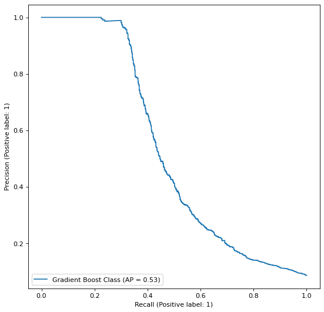

```python
plt.figure(figsize=(8,8), dpi=80)
plot_precision_recall_curve(GBC_final_model, X_test_prepared, y_test, ax = plt.gca(),name = "Gradient Boost Class")
```

Usually, precision is more involved and directed towrads direct costs; the more the number of false positives is big, the more cost per true positive we will have. In our case, not being capable of correctly classifying the true positive rates has a great impact on the company, as more people getting promoted means higher salaries, more higher positions needed regardless if it's feasible or not, resutructuring of teams, the need of new employees to fill the old positions left and many other things. All these factors will lead to financial burden in the first place and also it might lead to conflict of interest inside the company itself and between the employees as some poeple who doesn't derserve any promotion might be labeled suitable for promotion. The precision recall cusrves shows us also, that achieving high recall is proportionally related to a decrease in the precision, the thing which is not desired in our case.